# numpy

## Basics

```python
import numpy as np
```

Erzeuge ein Array `a` mit den Werten

2 3 2 4  
3 4 9 3  
4 0 1 4

```python
a = np.array([2, 3, 2, 4, 3, 4, 9, 3, 4, 0, 1, 4])
```

Bestimme die Dimensionen des Arrays

```python
a.shape
```

```
(12,)
```

Bestimme die `len` des Arrays

```python
len(a)
```

```
12
```

## Arrayerzeugung

Erzeuge ein Array der Zahlen von 1 bis 5

```python
np.array(range(1,6))
```

```
array([1, 2, 3, 4, 5])
```

Erzeuge ein Array der Länge 10, sodass `a[0] = 2, a[9] = 5` und die Elemente des Arrays eine arithmetische Folge bilden

```python
np.linspace(2,5,10)
```

```
array([2.        , 2.33333333, 2.66666667, 3.        , 3.33333333,
       3.66666667, 4.        , 4.33333333, 4.66666667, 5.        ])
```

Erzeuge ein `(3, 3)`-Array, dessen Einträge alle 1 sind

```python
np.ones((3,3))
```

```
array([[1., 1., 1.],
       [1., 1., 1.],
       [1., 1., 1.]])
```

Erzeuge eine `(4, 4)`-Einheitsmatrix

```python
np.eye(4)
```

```
array([[1., 0., 0., 0.],
       [0., 1., 0., 0.],
       [0., 0., 1., 0.],
       [0., 0., 0., 1.]])
```

```python
a = np.zeros((2,8))
a[:,4] = 1
a
```

```
array([[0., 0., 0., 0., 1., 0., 0., 0.],
       [0., 0., 0., 0., 1., 0., 0., 0.]])
```

## Visualisierung

Erzeuge ein Array `x` der Länge 100, sodass `x[0] = 0, x[99] = 2π` und die Elemente des Arrays eine arithmetische Folge bilden

```python
x = np.linspace(0, 2*np.pi, 100)
```

Erzeuge ein Array `y`, sodass `y[i] = sin(x[i])`

```python
y = np.sin(x)
```

Wir importieren *Seaborn* für einfache Graphiken und plotten unsere Funktion

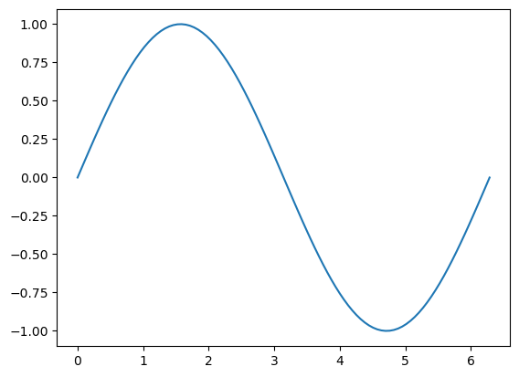

```python
import seaborn as sns
sns.lineplot(x=x, y=y)
```

## Indizierung und Slicing

Erzeuge ein Array `a` mit den Werten

2 3 2 4  
3 4 9 3  
4 0 1 4

```python
a = np.array([[2,3,2,4],[3,4,9,3],[4,0,1,4]])
```

Selektiere die 2. Zeile

```python
a[1]
```

```
array([3, 4, 9, 3])
```

Selektiere die 3. Spalte

```python
a[:,2]
```

```
array([2, 9, 1])
```

Selektiere die Matrix

4 9 3  
0 1 4

```python
a[1:3,1:]
```

```
array([[4, 9, 3],
       [0, 1, 4]])
```

Ermittle die Spannweite der Elemente von a

```python
np.ptp(a)
```

```
np.int64(9)
```

Erzeuge aus a den Output

```python
result = np.zeros_like(a, dtype=bool)
result[0, [0,2,3]] = True
result[2, [1,2]] = True
result
```

```
array([[ True, False,  True,  True],
       [False, False, False, False],
       [False,  True,  True, False]])
```

Erzeuge aus a das Array

`[2, 2, 4, 4, 4, 0, 4]`

```python
a.flat[[0,2,3,5,8,9,11]]
```

```
array([2, 2, 4, 4, 4, 0, 4])
```

Erzeuge aus einer `zeros`-Matrix durch Slicing das Array

2 0 1 0  
2 0 1 0  
2 0 3 3

```python
a = np.zeros((3,4))
a[:,0] = 2
a[0:2,2] = 1
a[2,2:4] = 3
a
```

```
array([[2., 0., 1., 0.],
       [2., 0., 1., 0.],
       [2., 0., 3., 3.]])
```

## Aggregatfunktionen

Erzeuge ein Array a mit den Werten

2 3 2 4  
3 4 9 3  
4 0 1 4

```python
a = np.array([[2,3,2,4],[3,4,9,3],[4,0,1,4]])
```

Berechne die Summe aller Werte

```python
np.sum(a)
```

```
np.int64(39)
```

Erzeuge ein Array, welches die Summe jeder Spalte enthält

```python
np.sum(a, axis=0)
```

```
array([ 9,  7, 12, 11])
```

Erzeuge ein Array, welches das Minimum jeder Zeile enthält

```python
np.min(a, axis=1)
```

```
array([2, 3, 0])
```